# Tugas Unsupervised Learning

Dinda Dwi Anugrah Pertiwi

2026-03-17

# Model Based Clustering

## Pendahuluan

*Model based clustering* merupakan metode pengelompokan data yang menggunakan pendekatan model statistik. Metode ini mengasumsikan bahwa data berasal dari beberapa kluster, di mana setiap kluster memiliki pusat (*mean*) dan pola penyebaran tertentu yang digambarkan melalui matriks kovarians. Pusat kluster direpresentasikan oleh vektor nilai rata-rata dari setiap variabel, sedangkan matriks kovarians menunjukkan variasi serta bentuk penyebaran data dalam kluster.

### GMM

Pendekatan ini umumnya menggunakan *Gaussian Mixture Model* (GMM), yaitu model probabilistik yang mengasumsikan bahwa setiap titik data memiliki peluang tertentu untuk menjadi anggota suatu kluster. Dengan demikian, keanggotaan suatu data tidak bersifat mutlak pada satu kluster saja, melainkan dinyatakan dalam bentuk probabilitas. Hal ini memungkinkan *model based clustering* untuk menangani kondisi di mana batas antar kluster tidak selalu jelas atau saling tumpang tindih.

Dibandingkan dengan metode klusterisasi lain seperti k-means, pendekatan berbasis model memiliki beberapa keunggulan.

- GMM memungkinkan titik data dimasukkan ke dalam kluster untuk mengakui bahwa batas-batas antar kluster tidak selalu terdefinisi dengan baik.
- GMM mampu menentukan jumlah kluster secara otomatis melalui proses inferensi, berbeda dengan metode kmeans yang mengharuskan penentuan jumlah kluster terlebih dahulu.
- Berkat penggunaan matriks kovariat, GMM cukup fleksibel untuk menangani kumpulan kluster dengan berbagai bentuk dan orientasi.

### Algoritma

Algoritma:

- Inisialisasi: menginisialisasi parameter seperti rata-rata (*mean*) atau matriks kovarians dengan menentukan jumlah kluster (*k*).
- Langkah Ekspektasi (*E*): menetapkan setiap titik data ke dalam kluster berdasarkan parameter saat ini, dengan mempertimbangkan probabilitas titik tersebut menjadi anggota setiap kluster.
- Langkah Maksimisasasi (*M*): memperbarui parameter (*mean* dan *kovarians*) berdasarkan penugasan kluster saat ini
- Mengulangi langkah 2 dan 3: proses ini diiterasikan hingga mencapai konvergensi (perubahan parameter sudah sangat kecil)

## Implementasi

```r
library(mclust)
library(ggplot2)
library(factoextra)
```

### Data Multishape

```r
data_gmm <- factoextra::multishapes
multishapes <- multishapes[1:800,]
model_gmm <- Mclust(multishapes, G = 3)
summary(model_gmm)
```

[output not shown]

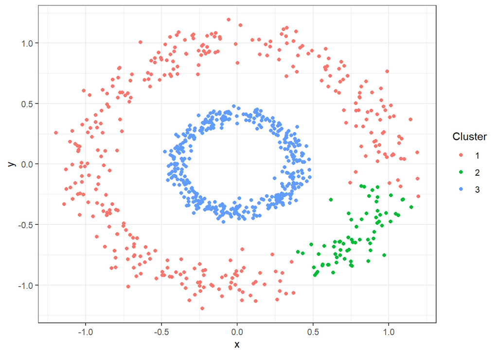

```r
model_cluster <- predict(model_gmm)$classification
ggplot(data = multishapes, aes(x=x, y=y)) +
  geom_point(aes(col = as.factor(model_cluster))) +
  theme_bw() +
  labs(col = "Cluster")
```

*Model Gaussian finite mixture*, khususnya Mclust dengan 3 komponen, diterapkan pada dataset yang terdiri dari 800 observasi dengan menggunakan algoritma *Expectation Maximization* (EM).

- Nilai log-likelihood, yang merupakan ukuran kesesuaian model terhadap data, adalah sekitar -1425.21.
- Nilai BIC (*Bayesian Information Criterion*) dan ICL (*Integrated Completed Likelihood*) masing-masing sebesar -2944.005 dan -3011.78. Kedua metrik ini digunakan untuk mengevaluasi kualitas model, di mana nilai yang lebih besar menunjukkan kesesuaian model yang lebih baik.
- Model ini memiliki 14 derajat kebebasan, dan tabel klusterisasi menunjukkan bahwa data terbagi menjadi tiga kluster, yaitu 331 observasi pada kluster 1, 69 observasi pada kluster 2, dan 400 observasi pada kluster 3.

Secara keseluruhan, model ini menunjukkan bahwa data dapat direpresentasikan dengan tiga kluster yang berbeda, di mana sebagian besar observasi berada pada kluster 1 dan kluster 3, sementara kluster 2 memiliki jumlah observasi yang lebih sedikit dibandingkan kluster lainnya.

### Data Iris

```r
data_gmm <- datasets::iris
data_iris <- iris[,1:4]
model_gmm <- Mclust(data_iris, G = 3)
summary(model_gmm)
```

```
## ----------------------------------------------------
## Gaussian finite mixture model fitted by EM algorithm
## ----------------------------------------------------
##
## Mclust VEV (ellipsoidal, equal shape) model with 3 components:
##
##  log-likelihood   n df       BIC       ICL
##        -186.074 150 38 -562.5522 -566.4673
##
## Clustering table:
##  1  2  3
## 50 45 55
```

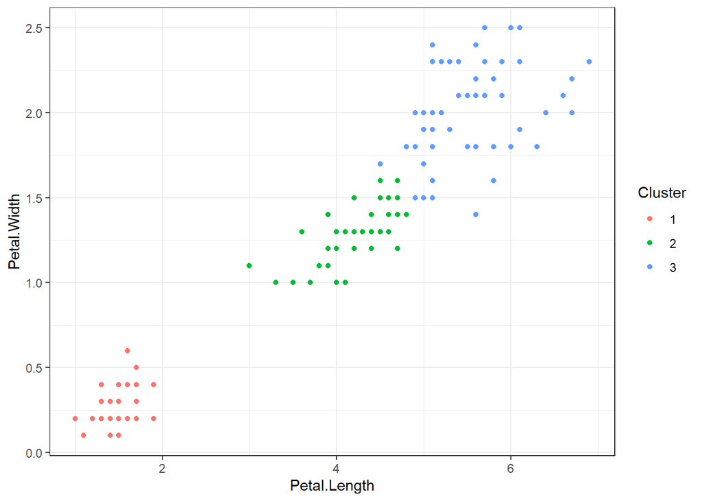

```r
model_cluster <- predict(model_gmm)$classification
ggplot(data = data_iris, aes(x= Petal.Length, y= Petal.Width)) +
  geom_point(aes(col = as.factor(model_cluster))) +
  theme_bw() +
  labs(col = "Cluster")
```

*Model Gaussian finite mixture*, khususnya Mclust VEV dengan 3 komponen, diterapkan pada dataset yang terdiri dari 150 observasi menggunakan algoritma *Expectation Maximization* (EM).

- Nilai log-likelihood, yang merupakan ukuran kesesuaian model terhadap data, adalah sekitar -186.074.
- Nilai BIC (*Bayesian Information Criterion*) dan ICL (*Integrated Completed Likelihood*) masing-masing sebesar -562.5522 dan -566.4673. Kedua metrik ini digunakan untuk mengevaluasi kualitas model, di mana nilai yang lebih besar menunjukkan kesesuaian model yang lebih baik dalam merepresentasikan struktur data.
- Model ini memiliki 38 derajat kebebasan, dan tabel klusterisasi menunjukkan bahwa data terbagi menjadi tiga kluster, yaitu 50 observasi pada kluster 1, 45 observasi pada kluster 2, dan 55 observasi pada kluster 3.

Secara keseluruhan, hasil ini menunjukkan bahwa data dapat direpresentasikan oleh tiga kluster yang berbeda, dengan jumlah observasi yang relatif seimbang pada masing-masing klaster. Model VEV (ellipsoidal dengan bentuk yang sama) menunjukkan bahwa setiap kluster memiliki orientasi yang berbeda namun mempertahankan bentuk yang serupa.